# Reproducible Research: Peer Assessment 1

## 1. Loading and preprocessing the data

```r
if (!file.exists("activity.csv")) {
  if (!file.exists("activity.zip")) {
    download.file(
      "https://d396qusza40orc.cloudfront.net/repdata%2Fdata%2Factivity.zip",
      "activity.zip")
  }
  unzip("activity.zip")
}
activity <- read.csv("activity.csv", colClasses=c("numeric","Date","numeric"))
```

## 2. What is mean total number of steps taken per day?

Make a histogram of the total number of steps taken each day.

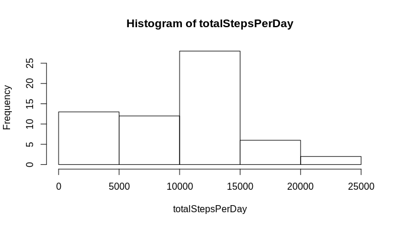

```r
totalStepsPerDay <- tapply(X=activity$steps,
                           INDEX=activity$date,
                           FUN=sum, na.rm=TRUE)
hist(totalStepsPerDay)
```

Calculate and report the median and mean steps per day.

```r
mean(totalStepsPerDay, na.rm=TRUE)
```

```
## [1] 9354.23
```

```r
median(totalStepsPerDay, na.rm=TRUE)
```

```
## [1] 10395
```

## 3. What is the average daily activity pattern?

Make a time-series plot of the 5-minute interval and average number of steps taken, averaged across all days.

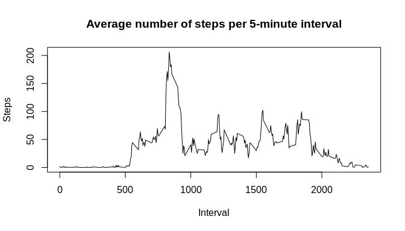

```r
aveStepsPerInterval <- tapply(X=activity$steps,
                              INDEX=activity$interval,
                              FUN=mean, na.rm=TRUE)
plot(type="l",
     x=names(aveStepsPerInterval), xlab="Interval",
     y=aveStepsPerInterval,        ylab="Steps",
     main="Average number of steps per 5-minute interval")
```

Which 5-minute interval, on average across all the days in the dataset, contains the maximum number of steps?

```r
names(which.max(aveStepsPerInterval))
```

```
## [1] "835"
```

## 4. Imputing missing values

Calculate and report the total number of missing values in the dataset (i.e. the total number of rows with NAs).

```r
sum(!complete.cases(activity))
```

```
## [1] 2304
```

Devise a strategy for filling in all of the missing values in the dataset.

- Strategy: use the mean for that 5-minute interval across all days

Create a new dataset that is equal to the original dataset but with the missing data filled in.

```r
new_activity <- data.frame(steps    = activity$steps,
                           date     = activity$date,
                           interval = activity$interval)

missing_rows      <- is.na(new_activity$steps)
missing_intervals <- as.character(new_activity[missing_rows, ]$interval)

new_activity[missing_rows, ]$steps <- aveStepsPerInterval[ missing_intervals ]
```

Make a histogram of the total number of steps taken each day.

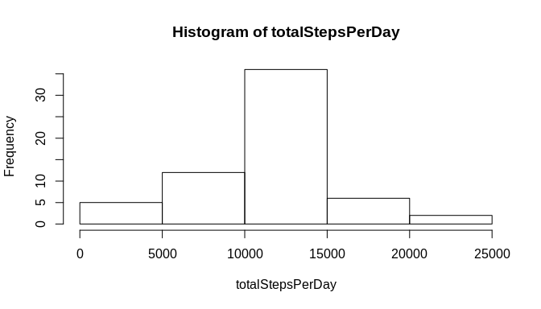

```r
totalStepsPerDay <- tapply(X=new_activity$steps,
                      INDEX=new_activity$date,
                      FUN=sum, na.rm=TRUE)
hist(totalStepsPerDay)
```

Calculate and report the mean and median total number of steps taken per day.

```r
mean(totalStepsPerDay, na.rm=TRUE)
```

```
## [1] 10766.19
```

```r
median(totalStepsPerDay, na.rm=TRUE)
```

```
## [1] 10766.19
```

Do these values differ from the estimates from the first part of the assignment?

- Yes, the mean and median are higher than the estimates from the first part.

## 5. Are there differences in activity patterns between weekdays and weekends?

Create a new factor variable in the dataset with two levels - “weekday” and “weekend” - indicating whether a given date is a weekday or weekend day.

```r
new_activity$w <-
  factor(weekdays(new_activity$date) %in% c("Saturday", "Sunday"),
         levels=c(TRUE, FALSE),
         labels=c("weekend", "weekday"))
```

Make a panel plot containing a time series plot (i.e. type=“l”) of the 5-minute interval (x-axis) and the average number of steps taken, averaged across all weekday days or weekend days (y-axis).

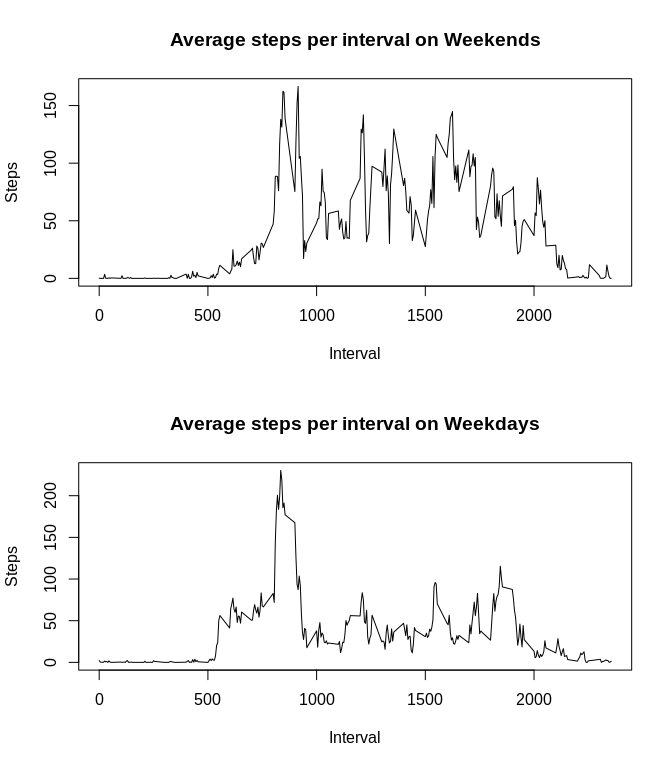

```r
aveStepsW <- data.frame(
                tapply(X=new_activity$steps,
                       INDEX=list(new_activity$interval, new_activity$w),
                       FUN=mean, na.rm=TRUE))
par(mfrow=c(2,1))

plot(type="l",
     x=rownames(aveStepsW), xlab="Interval",
     y=aveStepsW$weekend,   ylab="Steps",
     main="Average steps per interval on Weekends")

plot(type="l",
     x=rownames(aveStepsW), xlab="Interval",
     y=aveStepsW$weekday,   ylab="Steps",
     main="Average steps per interval on Weekdays")
```